# Assignment #1

## Question #5 - Functions & If Statments [11 marks]

1. Generate a vector containing *50* random numbers between *-200* and *200* (with replacement). [1 mark]

```r
(NUM = sample(-200:200, 50, replace = T))
```

```
 [1] -151  118  123 -109 -114  177 -200  -42   93    8  -25 -173  187  100 -159
[16]  169 -167 -195  -17   30   57  164 -150  -44 -173  -71 -183 -138  -36   53
[31]  -51  -22  198  -72   -1  -39  -14 -157  122   48  119  -72 -196 -182 -194
[46]  174  100   58  -95  194
```

2. Write your own version of the absolute value function which accepts a vector, and uses the `ifelse` statement to create a new vector where all negative values are replaced with their positive equivalent, then returns the new vector. Use the vector in **(a)**, and output the results. [2 marks]

```r
ABS <- function (Vec) {
  ifelse(Vec < 0, -Vec, Vec)
}
ABS(NUM)
```

```
 [1] 151 118 123 109 114 177 200  42  93   8  25 173 187 100 159 169 167 195  17
[20]  30  57 164 150  44 173  71 183 138  36  53  51  22 198  72   1  39  14 157
[39] 122  48 119  72 196 182 194 174 100  58  95 194
```

3. Write a function (called `f1`), which accepts two values `(x,y)`. If `x` is even, divide by *2*. If it’s odd, multiple by `y`. Use a complete if/else statement rather then ifelse. [2 marks]

```r
f1 <- function (x, y) {
  if (x %% 2 == 0) {
     return(x/2)
  } else {
    return(x*y)
  }
}
# (Optional) Correct function for part d
f2 <- function (x, y = 6) {
  vect = rep(0, length(x))
  for (i in 1:length(x)) {
    if (x[i] %% 2 == 0) {
      vect[i] = x[i]/2
    } else {
      vect[i]=(x[i]*y)
    }
  }
  vect
}
```

4. Use your function from *(c)* and pass it the vector from *(a)*. What happens? How might you resolve this issue? (You don’t need to provide code for this)[2 marks]

It shows: “Error in f1(NUM) : argument”y" is missing, with no default In addition: Warning message: In if (x%%2 == 0) { : the condition has length > 1 and only the first element will be used".

For the error, we need to introduce a default value for y when creating the function, like f1 <- function (x, y = 2). Moreover, the warning message says we need to consider x as a vector if we want to get the appropriate results. Using “for loop” before “if statement” can resolve this issue.

5. Create a function that accepts two arguments, an integer and a vector of integers. It returns `TRUE` if the integer is present in the vector, otherwise it returns `FALSE`. Make sure you pay careful attention to your placement of the return(`FALSE`) line in your function. [2 marks]

```r
IsThere <- function (int, VecInt) {
  Flag = FALSE
  for(i in VecInt) {
    if (i == int) {
      Flag = TRUE
      break
    }
  }
  Flag
}
IsThere(6,c(9,7,6,6,7,4,6))
```

```
[1] TRUE
```

```r
IsThere(1,c(9,7,6,6,7,4,6))
```

```
[1] FALSE
```

```r
IsThere(4,c(9,7,6,6,7,4,6))
```

```
[1] TRUE
```

6. Create a function that accepts two arguments, an integer and a vector of integers. It returns the count of the number of occurrences of the integer in the input vector. [2 marks]

```r
Counter <- function (int, VecInt) {
  count = 0
  for(i in VecInt) {
    if (i == int) {
      count = count + 1
    }
  }
  count
}
Counter(6,c(9,7,6,6,7,4,6))
```

```
[1] 3
```

```r
Counter(7,c(9,7,6,6,7,4,6))
```

```
[1] 2
```

```r
Counter(1,c(9,7,6,6,7,4,6))
```

```
[1] 0
```

```r
Counter(9,c(9,7,6,6,7,4,6))
```

```
[1] 1
```

## Question #6 - Native Plotting [3 marks]

Use `readr` to import the file primates.csv, and add the column names. Using the R native `plot()` display the data in a scatterplot with brainwt vs bodywt. Add a title & axis labels to the plot.

```r
library(readr)
(primates <- read_csv("primates.csv", skip = 1, col_names=c("Body_Weight","Brain_Weight")))
```

| Body_Weight | Brain_Weight |
| --- | --- |
| 10.0 | 115 |
| 207.0 | 406 |
| 62.0 | 1320 |
| 6.8 | 179 |
| 52.2 | 440 |

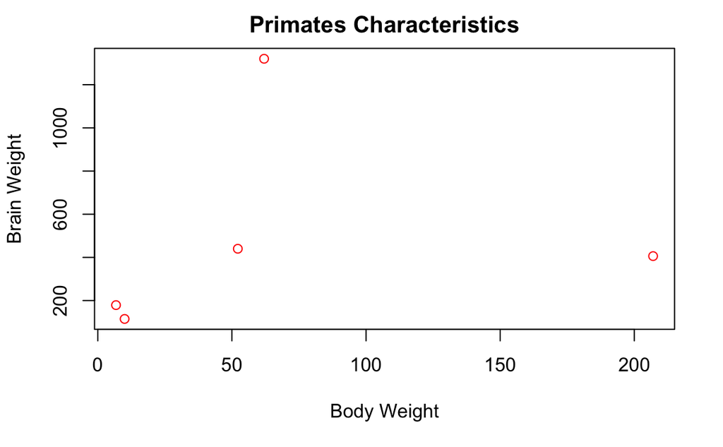

```r
plot(Brain_Weight ~ Body_Weight, data = primates, main = "Primates Characteristics", xlab = "Body Weight", ylab = "Brain Weight", col = "red")
```

## Question #7 - Basic Data Prep [6 marks]

1. Use the `readr` library to import enrollment.csv. Do not edit the file before importing, but notice you’ll probably need to skip some lines on import [1 mark]

```r
library(readr)
read_csv("enrollment.csv")
```

```
* `` -> ...1
* `` -> ...2
* `` -> ...4
```

| ...1 | ...2 | GTA Postings for COIS | ...4 |
| --- | --- | --- | --- |
| NA | NA | 2016/17 | NA |
| Year | Term | Course | Enrollment |
| 1 | F | COIS 1020H | 60 |
| 2 | F | COIS 2020H | 70 |
| 2 | F | COIS 2320H | 40 |
| 2 | F | COIS-ADMN 2620H | 80 |
| 2 | F | COIS 2830H | 100 |
| 3 | F | COIS 3030H | 40 |
| 3 | F | COIS 3320H | 35 |
| 3 | F | COIS 3380H | 30 |

[output cut: 15 more lines]

2. Give the columns proper names (they represent course year, term, course code, and enrollment). [1 mark]

```r
(enrollment <- read_csv("enrollment.csv",col_names=c("Year","Term","Course","Enrollment"),skip=3))
```

| Year | Term | Course | Enrollment |
| --- | --- | --- | --- |
| 1 | F | COIS 1020H | 60 |
| 2 | F | COIS 2020H | 70 |
| 2 | F | COIS 2320H | 40 |
| 2 | F | COIS-ADMN 2620H | 80 |
| 2 | F | COIS 2830H | 100 |
| 3 | F | COIS 3030H | 40 |
| 3 | F | COIS 3320H | 35 |
| 3 | F | COIS 3380H | 30 |
| 3 | F | COIS 3400H | 80 |
| 3 | F | COIS-ADMN 3850H | 60 |

[output cut: 13 more lines]

3. Convert year and term into Factors with more meaningful values. [1 mark]

```r
(enrollment$Year = as.factor(enrollment$Year))
```

```
 [1] 1 2 2 2 2 3 3 3 3 3 4 1 1 1 2 2 2 3 3 3 3 4 4
Levels: 1 2 3 4
```

```r
(enrollment$Term = as.factor(enrollment$Term))
```

```
 [1] F F F F F F F F F F F W W W W W W W W W W W W
Levels: F W
```

4. Use the aggregate function to determine the sum of enrollments by year and term. [1 mark]

```r
TotalYearByTerm <- aggregate(x = enrollment$Enrollment, by = list(enrollment$Year, enrollment$Term), sum)
colnames(TotalYearByTerm) <- c("Year", "Term", "Enrollment")
TotalYearByTerm
```

| Year | Term | Enrollment |
| --- | --- | --- |
| 1 | F | 60 |
| 2 | F | 290 |
| 3 | F | 245 |
| 4 | F | 20 |
| 1 | W | 295 |
| 2 | W | 230 |
| 3 | W | 155 |
| 4 | W | 45 |

5. Graph your results professionally in a manner of your choice. [2 marks]

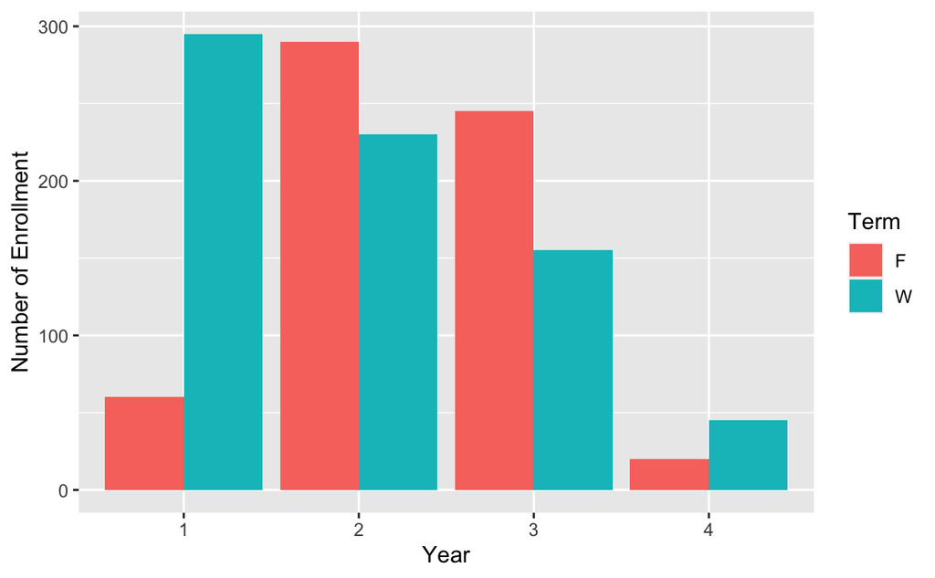

```r
library(ggplot2)
ggplot(data = TotalYearByTerm) + geom_bar(mapping = aes(x = Year, y = Enrollment, fill = Term), stat="identity", position = "dodge") + ylab("Number of Enrollment")
```